# Actitudes hacia los inmigrantes por parte de las y los chilenos

Ornella Quero

2022-12-06

- Institución: Universidad Alberto Hurtado.
- Carrera: Sociología.
- Curso: Análisis de Datos con R.
- Docente: Valentina Andrade de la Horra.
- Ayudantes: Dafne Jaime

### ABSTRACT.

La siguiente investigación trata sobre las actitudes de los chilenos hacia los inmigrantes que viven en el país, ya sea refiriendose a ellos como un general de inmigrantes o como peruanos, haitianos y venezolanos residentes en Chile. Para ello, se analizó los datos de la encuesta elsoc a través de gráficos y tablas de contingencia que permitió relacionar correctamente las variables.

### INTRODUCCION.

En los últimos años, Chile ha sido el destino de miles de migrantes latinoamericanos que por diferentes motivos deciden dejar su país y encontrar nuevos rumbos. Éste fenómeno ha generado distintas reacciones por parte de la población chilena puesto que hay personas que están a favor de su ingreso, otras que piden que el ingreso al país sea con ciertas restricciones y aquellos que simplemente no quieren que lleguen más inmigrantes al territorio chileno. Debido al incremento del porcentaje de extranjeros en el país y a las prácticas con las que se les relaciona es posible identificar la presencia de actitudes negativas por parte de las y los chilenos hacia ellos. Es por esta razón, que en el presente trabajo se realiza un análisis de estas actitudes, medidas a través del grado de confianza y simpatía que sienten los chilenes hacia los inmigrantes como también mediante el grado de acuerdo con que su ingreso debe tener ciertas restricciones y que su llegada aumenta el desempleo en el país. Además, estas cuatro variables serán analizadas según sexo, tramo de edad y ellas dos en conjunto. El principal objetivo es identificar en que medida existen actitudes negativas hacia los inmigrantes y cómo éstas se comportan según sexo y edad en la población.

Para hacer esto posible, se utilizó el dataset ELSOC_W05_v1.0_SPSS, generado el año 2021 por ELSOC, el cual es un estudio que mediante una muestra representativa pretende analizar varias dimensiones sociales, atendiendo a los cambios que se producen gracias a su tipo de diseño longitudinal (ELSOC, 2021).

### ANÁLISIS.

#### *Gráfico 1*

#### Grado de confianza hacia los inmigrantes por parte de la población chilena

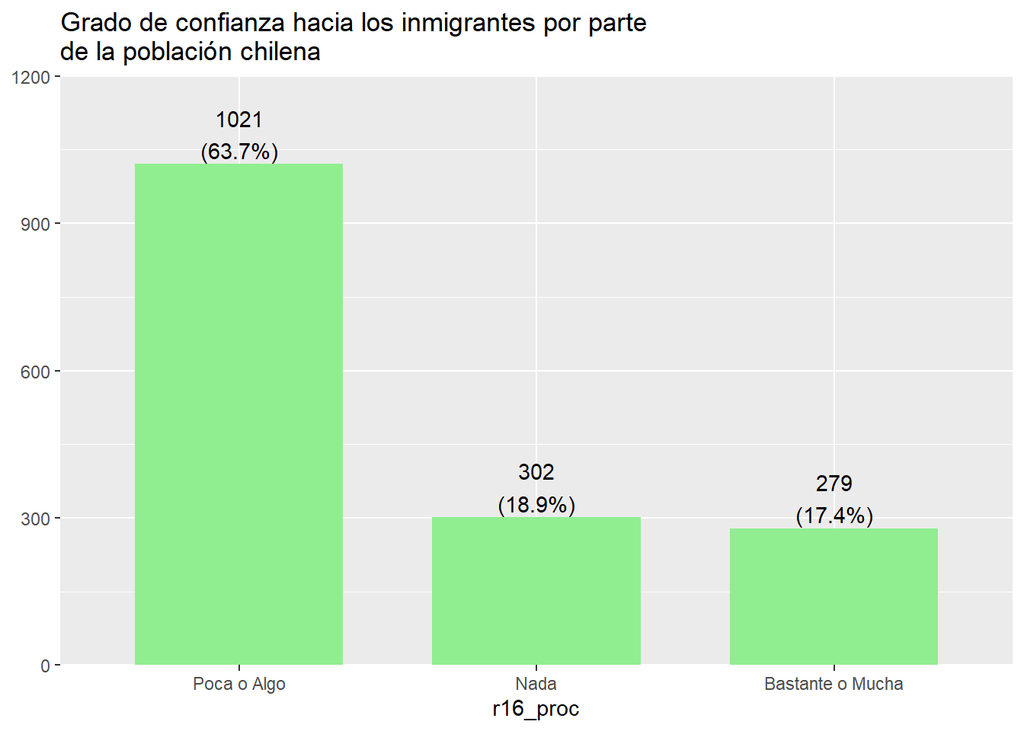

Aproximadamente el 64% de los encuestados dice sentir poco o algo de confianza hacia los inmigrantes, mientras que el 19% aprox. dice no sentir nada de confianza hacia ellos, siendo mayor al porcentaje de encuestado que siente mucha confianza (17% aprox.). Por lo tanto, cerca del 83% de la población chilena siente poco, algo o nada de confianza hacia las personas inmigrantes que están en Chile.

#### *Gráfico 2*

#### Grado de simpatia por peruanos, haitianos y venezolanos que viven en Chile

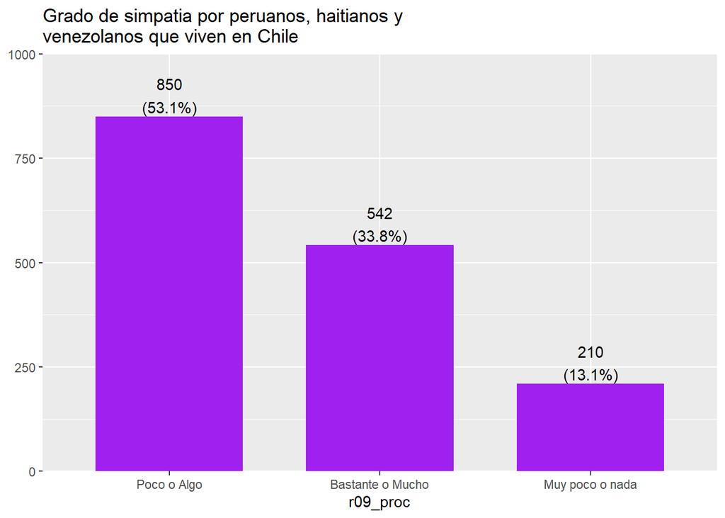

El 33,8% de los encuestados siente mucha simpatia por peruanos, haitianos y venezolanos que viven en Chile, al contrario de aquellos que sienten poca (53,1%) y muy poca o nada de siempatia (13,1%)

#### *Gráfico 3*

#### Grado de acuerdo que con llegada de peruanos, haitianos y venezolanos aumenta el desempleo

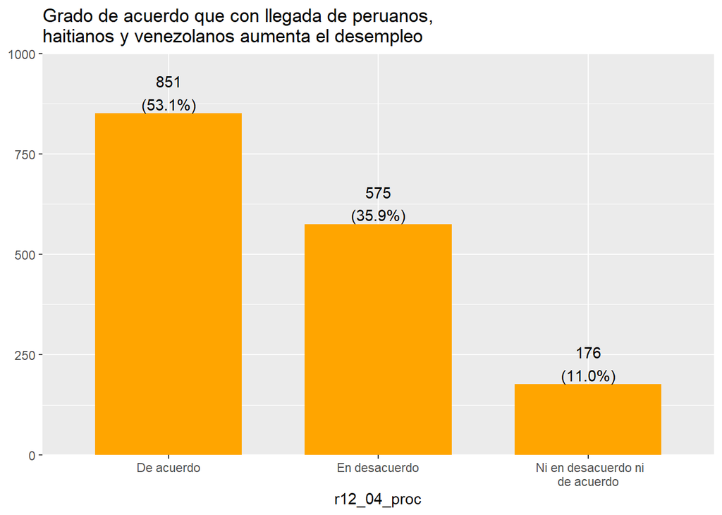

Más del 50% de los encuestados está de acuerdo con la frase que afirma que con la llegada de peruanos, haitianos y venezolanos aumenta el desempleo, el 11% está indeciso y el 36% aprox. está en desacuerdo con la frase.

#### *Gráfico 4*

#### Grado de acuerdo con establecer restricciones para el ingreso de migrantes

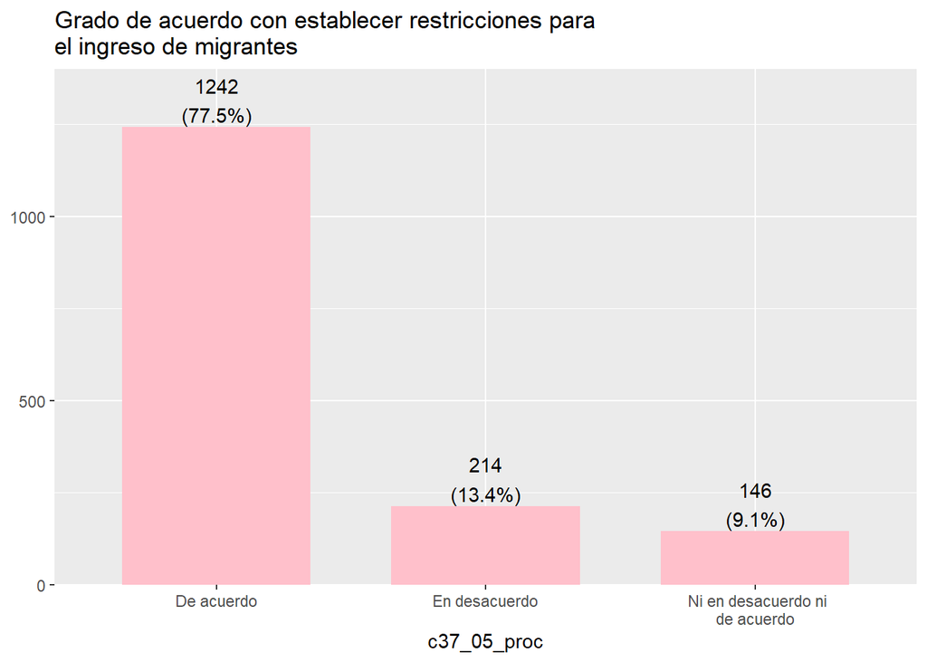

Casi el 78% de los encuestados dice estar de acuerdo con que se establezcan restricciones para el ingreso de migrantes al país, el 13,4% está en desacuerdo con esta medida y el 9% se mantiene neutral.

#### *Gráfico 5*

#### Grado de confianza hacia inmigrantes según tramo etario

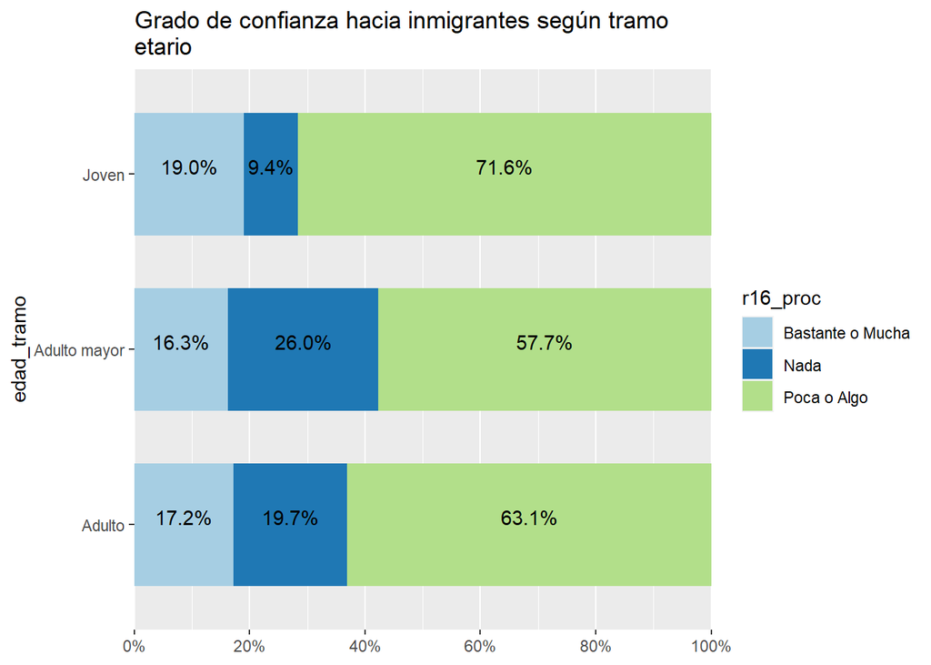

En general, los jovenes son quienes tienen más confianza hacia los inmigrantes, siendo mucha con un 19% y poca o algo el 72% aprox. En cambio, el adulto mayor es el que menos confianza tiene, siendo nada de confianza hacia los inmigrantes un 26% y poca o algo el 58%. Asimismo, se podría decir que adulto es un intermedio de los porcentajes de jovenes y adultos mayores, siendo mucha confianza el 17%, nada de confianza el 19% y poca o algo el 63%.

#### *Tabla 1*

#### Grado de acuerdo que con llegada de peruanos, haitianos y venezolanos aumenta el desempleo según sexo y tramo de edad.

Tabla de contingencia: Grado de acuerdo que con llegada de peruanos, haitianos y venezolanos aumenta el desempleo según sexo y tramo de edad

| r12_04_proc | sexo_edad_tramo |  |  |  |  |  | Total |  |
| --- | --- | --- | --- | --- | --- | --- | --- | --- |
|  | Adulta mayor | Adulto mayor | Hombre adulto | Hombre joven | Mujer adulta | Mujer joven |  |  |
| Ni en desacuerdo ni de acuerdo | 18 5.8 % | 12 6.8 % | 20 8.6 % | 33 18.4 % | 56 12.2 % | 37 15 % |  | 176 11 % |
| De acuerdo | 200 64.7 % | 98 55.7 % | 120 51.7 % | 63 35.2 % | 270 58.8 % | 100 40.5 % | 851 53.1 % |  |
| En desacuerdo | 91 29.4 % | 66 37.5 % | 92 39.7 % | 83 46.4 % | 133 29 % | 110 44.5 % | 575 35.9 % |  |
| Total | 309 100 % | 176 100 % | 232 100 % | 179 100 % | 459 100 % | 247 100 % | 1602 100 % |  |

Según sexo y tramo de edad, casi todos tienen el porcentanje más alto en la alternativa de de acuerdo con la afirmación a excepción del hombre y la mujer joven que tan solo está de acuerdo el 35% y el 40%, estando mayoritariamente el 46% y el 44,5% en desacuerdo con la frase. Por otro lado, la adulta mayor es quien más se encuentra de acuerdo con la frase de que con la llegada de inmigrantes aumenta el desempleo, seguida por la mujer adulta.

#### *Tabla 2*

#### Grado de simpatia por peruanos, haitianos y venezolanos que viven en Chile según sexo

Tabla de contingencia: Grado de simpatia por peruanos, haitianos y venezolanos que viven en Chile

| r09_proc | m0_sexo |  | Total |  |
| --- | --- | --- | --- | --- |
|  | Hombre | Mujer |  |  |
| Bastante o Mucho | 218 37.1 % | 324 31.9 % |  | 542 33.8 % |
| Muy poco o nada | 60 10.2 % | 150 14.8 % | 210 13.1 % |  |
| Poco o Algo | 309 52.6 % | 541 53.3 % | 850 53.1 % |  |
| Total | 587 100 % | 1015 100 % | 1602 100 % |  |

### CONCLUSIÓN.

A través del análisis realizado se puede afirmar que predominan las actitudes y setimientos negativos hacia los inmigrantes en general como también en especifico a aquellos que son peruanos, haitianos y venezolanos. Esto se demostró mediante los datos que arrojaron los gráficos en donde cerca del 83% de la población chilena siente poco, algo o nada de confianza hacia las personas inmigrantes que están en Chile, el 53,1% siente poca simpatia por ellos, más del 50% cree que con su llegada aumenta el desempleo y un 78% esta de acuerdo con que se establezcan restricciones para su ingreso. Asimismo, quienes más desconfian son los adultos mayores y quienes menos simpatizan son las mujeres, a diferencia de los hombres. De esta manera, se puede inferir que el incremento del porcentaje de extranjeros que viven en Chile produce una reacción negativa y hostil por parte de los chilenos, ya sea por la formalidad de su estancia como por las costumbres que ellos tienen, sin mencionar los delitos con los cuales se les puede asociar justa o injustamente.

### REFERENCIAS.

- González, R., Muñoz, E., & Mackenna, B. (2019). Cómo quieren en Chile al amigo cuando es forastero: actitudes de los chilenos hacia la inmigración. Isabel Aninat and Rodrigo Vergara (des), Inmigración en Chile. Una mirada multidimensional, 321-346.
- Encuesta Longitudinal Elsoc 2021.